# Practical Machine Learning Project

Rasul Balayev

1/27/2021

## Introduction

Using devices such as Jawbone Up, Nike FuelBand, and Fitbit it is now possible to collect a large amount of data about personal activity relatively inexpensively. These type of devices are part of the quantified self movement – a group of enthusiasts who take measurements about themselves regularly to improve their health, to find patterns in their behavior, or because they are tech geeks. One thing that people regularly do is quantify how much of a particular activity they do, but they rarely quantify how well they do it. In this project, your goal will be to use data from accelerometers on the belt, forearm, arm, and dumbell of 6 participants.

## Loading the data,libraries and exploratory analysis

### Loading libraries

```r
library(caret)
library(rattle)
library(randomForest)
```

```r
library(corrplot)
library(knitr)
library(rpart)
library(rpart.plot)
set.seed(123)
```

```r
datatrain <- read.csv(url("https://d396qusza40orc.cloudfront.net/predmachlearn/pml-training.csv"),header=TRUE)
datatest <- read.csv(url("https://d396qusza40orc.cloudfront.net/predmachlearn/pml-testing.csv"),header=TRUE)
dim(datatest)
```

```
## [1]  20 160
```

```r
head(datatest)
```

```
##   X user_name raw_timestamp_part_1 raw_timestamp_part_2   cvtd_timestamp
## 1 1     pedro           1323095002               868349 05/12/2011 14:23
## 2 2    jeremy           1322673067               778725 30/11/2011 17:11
## 3 3    jeremy           1322673075               342967 30/11/2011 17:11
## 4 4    adelmo           1322832789               560311 02/12/2011 13:33
## 5 5    eurico           1322489635               814776 28/11/2011 14:13
## 6 6    jeremy           1322673149               510661 30/11/2011 17:12
##   new_window num_window roll_belt pitch_belt yaw_belt total_accel_belt
## 1         no         74    123.00      27.00    -4.75               20
## 2         no        431      1.02       4.87   -88.90                4
## 3         no        439      0.87       1.82   -88.50                5
## 4         no        194    125.00     -41.60   162.00               17
## 5         no        235      1.35       3.33   -88.60                3
## 6         no        504     -5.92       1.59   -87.70                4
##   kurtosis_roll_belt kurtosis_picth_belt kurtosis_yaw_belt skewness_roll_belt
```

[output cut: 251 more lines]

```r
head(datatrain)
```

```
##   X user_name raw_timestamp_part_1 raw_timestamp_part_2   cvtd_timestamp
## 1 1  carlitos           1323084231               788290 05/12/2011 11:23
## 2 2  carlitos           1323084231               808298 05/12/2011 11:23
## 3 3  carlitos           1323084231               820366 05/12/2011 11:23
## 4 4  carlitos           1323084232               120339 05/12/2011 11:23
## 5 5  carlitos           1323084232               196328 05/12/2011 11:23
## 6 6  carlitos           1323084232               304277 05/12/2011 11:23
##   new_window num_window roll_belt pitch_belt yaw_belt total_accel_belt
## 1         no         11      1.41       8.07    -94.4                3
## 2         no         11      1.41       8.07    -94.4                3
## 3         no         11      1.42       8.07    -94.4                3
## 4         no         12      1.48       8.05    -94.4                3
## 5         no         12      1.48       8.07    -94.4                3
## 6         no         12      1.45       8.06    -94.4                3
##   kurtosis_roll_belt kurtosis_picth_belt kurtosis_yaw_belt skewness_roll_belt
```

[output cut: 251 more lines]

```r
dim(datatrain)
```

```
## [1] 19622   160
```

```r
inTrain  <- createDataPartition(datatrain$classe, p=0.7, list=FALSE)
trainset <- datatrain[inTrain, ]
testset  <- datatrain[-inTrain, ]
dim(trainset)
```

```
## [1] 13737   160
```

```r
dim(testset)
```

```
## [1] 5885  160
```

```r
NZV <- nearZeroVar(trainset)
trainset <- trainset[, -NZV]
testset  <- testset[, -NZV]
dim(trainset)
```

```
## [1] 13737   107
```

```r
dim(testset)
```

```
## [1] 5885  107
```

```r
NAvalue    <- sapply(trainset, function(x) mean(is.na(x))) > 0.95
trainset <- trainset[, NAvalue==FALSE]
testset  <- testset[, NAvalue==FALSE]
dim(trainset)
```

```
## [1] 13737    59
```

```r
dim(testset)
```

```
## [1] 5885   59
```

```r
## we don't need id values
trainset <- trainset[, -(1:5)]
testset  <- testset[, -(1:5)]
dim(trainset)
```

```
## [1] 13737    54
```

```r
dim(testset)
```

```
## [1] 5885   54
```

```r
set.seed(123)
crf <- trainControl(method="cv", number=3, verboseIter=FALSE)
mrf <- train(classe ~ ., data=trainset, method="rf",
                          trControl=crf)
mrf$finalModel
```

```
##
## Call:
##  randomForest(x = x, y = y, mtry = param$mtry)
##                Type of random forest: classification
##                      Number of trees: 500
## No. of variables tried at each split: 27
##
##         OOB estimate of  error rate: 0.23%
## Confusion matrix:
##      A    B    C    D    E  class.error
## A 3904    1    0    0    1 0.0005120328
## B    6 2648    3    1    0 0.0037622272
## C    0    7 2388    1    0 0.0033388982
## D    0    0    7 2245    0 0.0031083481
## E    0    0    0    5 2520 0.0019801980
```

```r
prf <- predict(mrf, newdata=testset)
confusionMatrix(table(testset$classe,prf))
```

```
## Confusion Matrix and Statistics
##
##    prf
##        A    B    C    D    E
##   A 1674    0    0    0    0
##   B    1 1135    3    0    0
##   C    0    2 1024    0    0
##   D    0    0    1  963    0
##   E    0    0    0    4 1078
##
## Overall Statistics
##
##                Accuracy : 0.9981
##                  95% CI : (0.9967, 0.9991)
##     No Information Rate : 0.2846
##     P-Value [Acc > NIR] : < 2.2e-16
##
##                   Kappa : 0.9976
##
##  Mcnemar's Test P-Value : NA
##
## Statistics by Class:
##
##                      Class: A Class: B Class: C Class: D Class: E
## Sensitivity            0.9994   0.9982   0.9961   0.9959   1.0000
## Specificity            1.0000   0.9992   0.9996   0.9998   0.9992
## Pos Pred Value         1.0000   0.9965   0.9981   0.9990   0.9963
## Neg Pred Value         0.9998   0.9996   0.9992   0.9992   1.0000
## Prevalence             0.2846   0.1932   0.1747   0.1643   0.1832
## Detection Rate         0.2845   0.1929   0.1740   0.1636   0.1832
## Detection Prevalence   0.2845   0.1935   0.1743   0.1638   0.1839
## Balanced Accuracy      0.9997   0.9987   0.9978   0.9978   0.9996
```

Random forest Accuracy : 0.9981

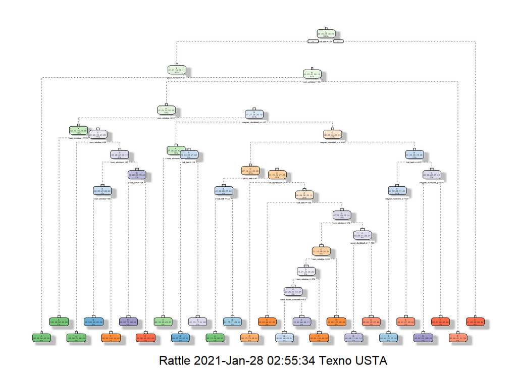

```r
set.seed(123)
dtree<- rpart(classe ~ ., data=trainset, method="class")
fancyRpartPlot(dtree)
```

```r
pdtree <- predict(dtree, newdata=testset, type="class")
confusionMatrix(table(pdtree, testset$classe))
```

```
## Confusion Matrix and Statistics
##
##
## pdtree    A    B    C    D    E
##      A 1459   86    0   13    2
##      B  104  855   61   75   51
##      C    0   57  856   37    3
##      D   92   81   99  759   86
##      E   19   60   10   80  940
##
## Overall Statistics
##
##                Accuracy : 0.8274
##                  95% CI : (0.8175, 0.8369)
##     No Information Rate : 0.2845
##     P-Value [Acc > NIR] : < 2.2e-16
##
##                   Kappa : 0.7823
##
##  Mcnemar's Test P-Value : NA
##
## Statistics by Class:
##
##                      Class: A Class: B Class: C Class: D Class: E
## Sensitivity            0.8716   0.7507   0.8343   0.7873   0.8688
## Specificity            0.9760   0.9387   0.9800   0.9273   0.9648
## Pos Pred Value         0.9353   0.7461   0.8982   0.6795   0.8476
## Neg Pred Value         0.9503   0.9401   0.9655   0.9570   0.9703
## Prevalence             0.2845   0.1935   0.1743   0.1638   0.1839
## Detection Rate         0.2479   0.1453   0.1455   0.1290   0.1597
## Detection Prevalence   0.2651   0.1947   0.1619   0.1898   0.1884
## Balanced Accuracy      0.9238   0.8447   0.9072   0.8573   0.9168
```

Decision tree Accuracy : 0.82

```r
set.seed(123)
cgbm <- trainControl(method = "repeatedcv", number = 5, repeats = 1)
mgbm  <- train(classe ~ ., data=trainset, method = "gbm",
                    trControl = cgbm, verbose = FALSE)
mgbm$finalModel
```

```
## A gradient boosted model with multinomial loss function.
## 150 iterations were performed.
## There were 53 predictors of which 53 had non-zero influence.
```

```r
pgbm <- predict(mgbm, newdata=testset)
 confusionMatrix(table(pgbm, testset$classe))
```

```
## Confusion Matrix and Statistics
##
##
## pgbm    A    B    C    D    E
##    A 1673    9    0    1    0
##    B    1 1117    8    7    2
##    C    0   12 1015   10    8
##    D    0    1    3  946    8
##    E    0    0    0    0 1064
##
## Overall Statistics
##
##                Accuracy : 0.9881
##                  95% CI : (0.985, 0.9907)
##     No Information Rate : 0.2845
##     P-Value [Acc > NIR] : < 2.2e-16
##
##                   Kappa : 0.985
##
##  Mcnemar's Test P-Value : NA
##
## Statistics by Class:
##
##                      Class: A Class: B Class: C Class: D Class: E
## Sensitivity            0.9994   0.9807   0.9893   0.9813   0.9834
## Specificity            0.9976   0.9962   0.9938   0.9976   1.0000
## Pos Pred Value         0.9941   0.9841   0.9713   0.9875   1.0000
## Neg Pred Value         0.9998   0.9954   0.9977   0.9963   0.9963
## Prevalence             0.2845   0.1935   0.1743   0.1638   0.1839
## Detection Rate         0.2843   0.1898   0.1725   0.1607   0.1808
## Detection Prevalence   0.2860   0.1929   0.1776   0.1628   0.1808
## Balanced Accuracy      0.9985   0.9884   0.9916   0.9894   0.9917
```

Generalized Boosted Model Accuracy: 0.9881

Finally it is more reasonable tu use Random forest

```r
predictTEST <- predict(mrf, newdata=datatest)
predictTEST
```

```
##  [1] B A B A A E D B A A B C B A E E A B B B
## Levels: A B C D E
```